# Alpha Diversity help

## Tutorial

You should go through the tutorial before attempting the problems. Make sure to read the tutorial to learn it.

## Tutorial Plots

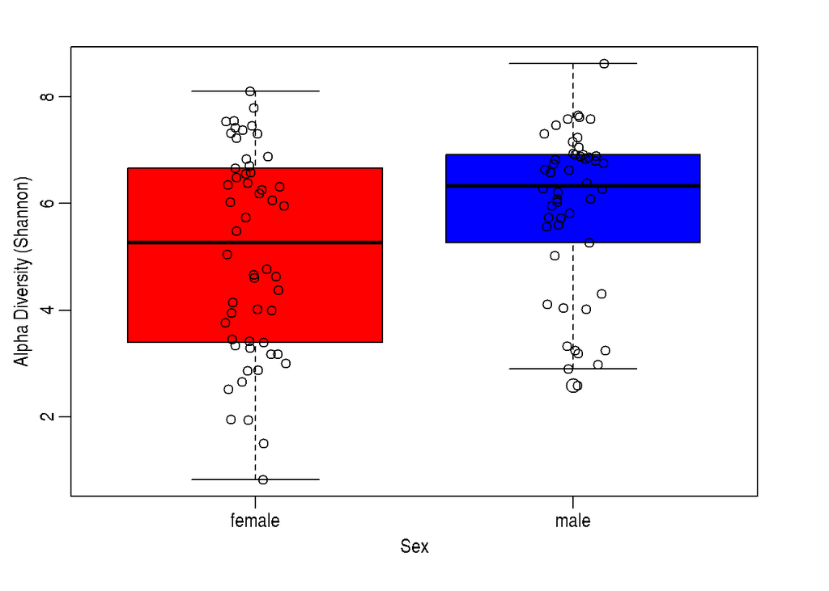

# Beeswarm Plots

If you get an error such as “there is no package called ‘beeswarm’” make sure to run install.packages(“beeswarm”) (or whichever is missing) and try again. You may need to upgrade your version of R as well.

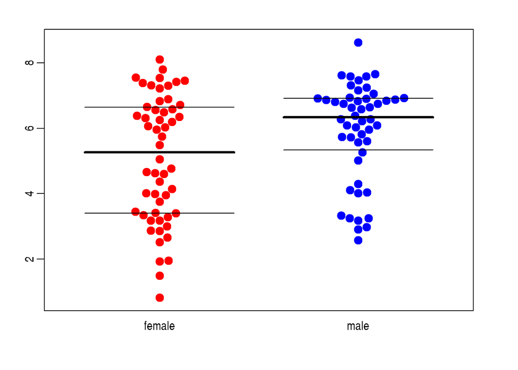

# Testing for normality

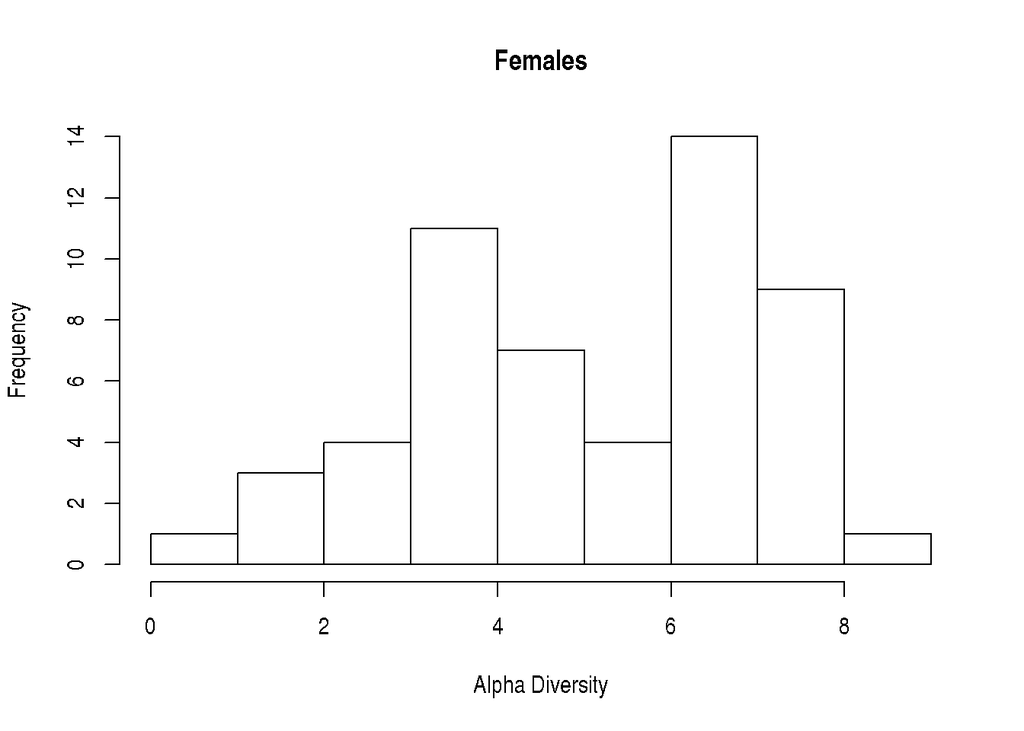

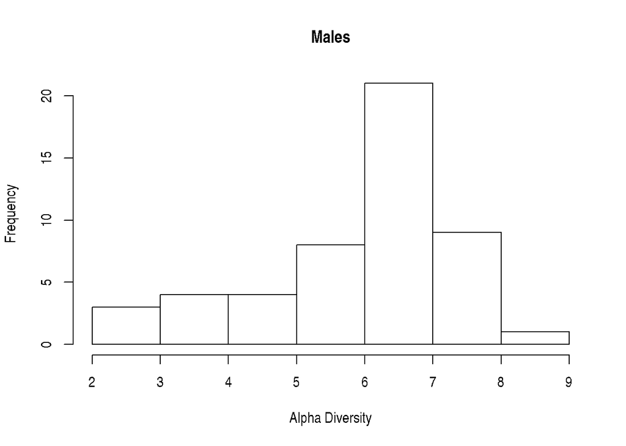

# Shapiro-Wilk Normality Test

```r
shapiro.test(females[,div_metric])
```

```
##
##  Shapiro-Wilk normality test
##
## data:  females[, div_metric]
## W = 0.94548, p-value = 0.01589
```

```r
shapiro.test(males[,div_metric])
```

```
##
##  Shapiro-Wilk normality test
##
## data:  males[, div_metric]
## W = 0.89734, p-value = 0.000393
```

# Mann-Whitney U Test

```
##
##  Wilcoxon rank sum test with continuity correction
##
## data:  females[, div_metric] and males[, div_metric]
## W = 1016, p-value = 0.03003
## alternative hypothesis: true location shift is not equal to 0
```

```
##         Mid_vagina_vs_Left_Retroauricular_crease
##                                     1.682015e-01
##                             Mid_vagina_vs_Saliva
##                                     7.431382e-12
##                 Mid_vagina_vs_Subgingival_plaque
##                                     3.715691e-12
##                              Mid_vagina_vs_Stool
##                                     2.600984e-11
##             Left_Retroauricular_crease_vs_Saliva
##                                     8.917659e-11
## Left_Retroauricular_crease_vs_Subgingival_plaque
##                                     2.600984e-11
##              Left_Retroauricular_crease_vs_Stool
##                                     5.164811e-10
##                     Saliva_vs_Subgingival_plaque
##                                     5.100514e-01
##                                  Saliva_vs_Stool
##                                     4.815795e-02
##                      Subgingival_plaque_vs_Stool
##                                     2.298969e-01
```

# FDR Correction

```
##         Mid_vagina_vs_Left_Retroauricular_crease
##                                     2.102519e-01
##                             Mid_vagina_vs_Saliva
##                                     3.715691e-11
##                 Mid_vagina_vs_Subgingival_plaque
##                                     3.715691e-11
##                              Mid_vagina_vs_Stool
##                                     6.502459e-11
##             Left_Retroauricular_crease_vs_Saliva
##                                     1.783532e-10
## Left_Retroauricular_crease_vs_Subgingival_plaque
##                                     6.502459e-11
##              Left_Retroauricular_crease_vs_Stool
##                                     8.608018e-10
##                     Saliva_vs_Subgingival_plaque
##                                     5.100514e-01
##                                  Saliva_vs_Stool
##                                     6.879708e-02
##                      Subgingival_plaque_vs_Stool
##                                     2.554410e-01
```

# Sink (write to file)

```
##
## Number of samples in each group:
```

```
##
## Left_Retroauricular_crease                 Mid_vagina
##                         21                         21
##                     Saliva                      Stool
##                         20                         21
##         Subgingival_plaque
##                         21
```

```
##
## Mean Alpha Diversity:
```

```
## Left_Retroauricular_crease                 Mid_vagina
##                   3.914519                   3.341589
##                     Saliva                      Stool
##                   6.586443                   6.915232
##         Subgingival_plaque
##                   6.721856
```

```
##
## Median Alpha Diversity:
```

```
## Left_Retroauricular_crease                 Mid_vagina
##                   4.019061                   3.398983
##                     Saliva                      Stool
##                   6.605251                   6.898571
##         Subgingival_plaque
##                   6.743908
```

```
##
## Standard Deviation:
```

```
## Left_Retroauricular_crease                 Mid_vagina
##                  1.1498917                  1.0272598
##                     Saliva                      Stool
##                  0.4681911                  0.8987179
##         Subgingival_plaque
##                  0.6914901
```

```
##
## Pairwise Mann-Whitney-Wilcoxon Tests were performed.
```

```
## Pairwise p-values are:
```

```
##         Mid_vagina_vs_Left_Retroauricular_crease
##                                     1.682015e-01
##                             Mid_vagina_vs_Saliva
##                                     7.431382e-12
##                 Mid_vagina_vs_Subgingival_plaque
##                                     3.715691e-12
##                              Mid_vagina_vs_Stool
##                                     2.600984e-11
##             Left_Retroauricular_crease_vs_Saliva
##                                     8.917659e-11
## Left_Retroauricular_crease_vs_Subgingival_plaque
##                                     2.600984e-11
##              Left_Retroauricular_crease_vs_Stool
##                                     5.164811e-10
##                     Saliva_vs_Subgingival_plaque
##                                     5.100514e-01
##                                  Saliva_vs_Stool
##                                     4.815795e-02
##                      Subgingival_plaque_vs_Stool
##                                     2.298969e-01
```

```
##
## FDR-corrected pairwise p-values are:
```

```
##         Mid_vagina_vs_Left_Retroauricular_crease
##                                     2.102519e-01
##                             Mid_vagina_vs_Saliva
##                                     3.715691e-11
##                 Mid_vagina_vs_Subgingival_plaque
##                                     3.715691e-11
##                              Mid_vagina_vs_Stool
##                                     6.502459e-11
##             Left_Retroauricular_crease_vs_Saliva
##                                     1.783532e-10
## Left_Retroauricular_crease_vs_Subgingival_plaque
##                                     6.502459e-11
##              Left_Retroauricular_crease_vs_Stool
##                                     8.608018e-10
##                     Saliva_vs_Subgingival_plaque
##                                     5.100514e-01
##                                  Saliva_vs_Stool
##                                     6.879708e-02
##                      Subgingival_plaque_vs_Stool
##                                     2.554410e-01
```

# Question 2

For question 2 you will change the covariate and the metric

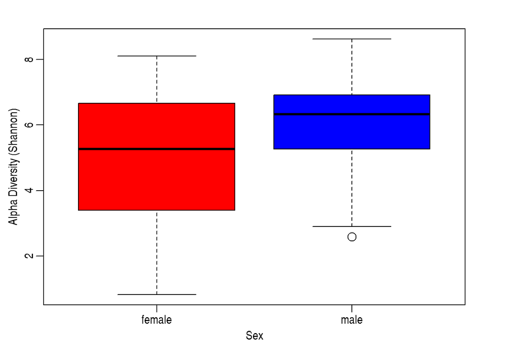

```r
# Change this next line!
cov1 <- 'Sex'
# And you will alternate this to make the 3 plots
div_metric <- "shannon"

# The rest of the code makes the box plot
par(mar=c(4,3,2,3),mgp=c(1.6,0.5,0))
cols <- c('red','blue')

# ALSO CHANGE YOUR LABELS!
boxplot(alpha[,div_metric] ~ metadata[,cov1],
        cex=1.5,
        ylab='Alpha Diversity (Shannon)',
        pch=21,
        col=cols,
        xlab='Sex')
```

# Troubleshooting

If you get an error that looks like this “Error in `[.data.frame`(metadata, , cov1) : undefined columns selected” then you aren’t using a valid column name. Type in View(metadata) to identify the column you wish to use. You may also be choosing the wrong diversity metric, you can use View(alpha) to see which are available.

# Question 3

Change the covariate and the diversity metric here. Remember to use View(alpha) and View(metadata) to see which columns are available, and that you have them spelled correctly and capitalized the same way

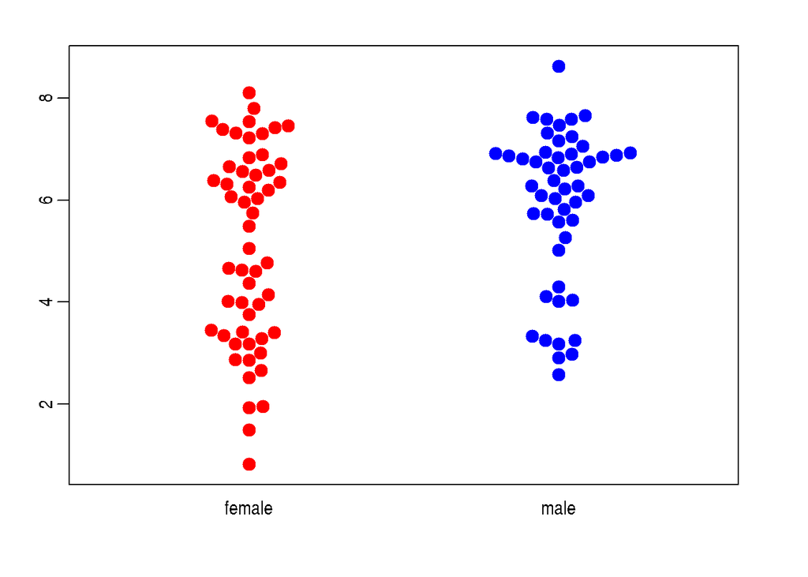

# Question 4

For this you will use the for loop for the Mann-Whitney test. You will have to change references from BodySite to the variable you want to test, and change the div_metric to test all of them asked for in the question

```r
groups <- unique(metadata[,'BodySite'])
div_metric <- "shannon"

pw.pvalues <- NULL
pw.names <- NULL

for(i in 1:(length(groups) - 1)){
            for(j in (i+1):length(groups)){
                ix.metric.i <- metadata[,'BodySite'] == groups[i]
                ix.metric.j <- metadata[,'BodySite'] == groups[j]
                pvalue <- wilcox.test(alpha[ix.metric.i,div_metric], alpha[ix.metric.j,div_metric])$p.value
                pw.pvalues <- c(pw.pvalues, pvalue)
                test.name <- paste(groups[i], "_vs_", groups[j],sep='')
                pw.names <- c(pw.names, test.name)
            }
}
names(pw.pvalues) <- pw.names

# When comparing multiple groups make sure to use FDR

fdr.pvalues <- p.adjust(pw.pvalues,'fdr')
fdr.pvalues
```

```
##         Mid_vagina_vs_Left_Retroauricular_crease
##                                     2.102519e-01
##                             Mid_vagina_vs_Saliva
##                                     3.715691e-11
##                 Mid_vagina_vs_Subgingival_plaque
##                                     3.715691e-11
##                              Mid_vagina_vs_Stool
##                                     6.502459e-11
##             Left_Retroauricular_crease_vs_Saliva
##                                     1.783532e-10
## Left_Retroauricular_crease_vs_Subgingival_plaque
##                                     6.502459e-11
##              Left_Retroauricular_crease_vs_Stool
##                                     8.608018e-10
##                     Saliva_vs_Subgingival_plaque
##                                     5.100514e-01
##                                  Saliva_vs_Stool
##                                     6.879708e-02
##                      Subgingival_plaque_vs_Stool
##                                     2.554410e-01
```

# Question 5

See previous powerpoint (few weeks ago), notes, or search on the internet.